Econometrics and Statistics (520K)

# Econometric Methods in Business and Economics

Practical Class (Winter 24/25)

by Domenic Franjic

# Exercise Sheet No 12

Regression Analysis of Time Series Data (Part 2)

## Set-Up

1) Create your (working) directory

Create a new folder on your computer in which you can save all necessary files, i.e., the data set, the R *script* with the implementation of your analysis and the R *helper function script* with some helper functions provided by us.

This folder, i.e., the path or directory of this folder, will be your so-called working directory.

2) Download the data set

Download the data sets `us_macro_data` and `us_urate_data` from ILIAS directly or by using the link below:

[Download `us_macro_data`](https://ilias.uni-hohenheim.de/goto.php?target=file_1558777_download&client_id=UHOH)

[Download `us_urate_data`](https://ilias.uni-hohenheim.de/goto.php?target=file_1561369_download&client_id=UHOH)

Save the data set into a (working) directory of your choice.

3) Prepare *script*

Open a new R *script* and save it into into your (working) directory.

Run the following code chunk to prepare your R *script*, i.e., to clear the work space and set your working directory.

```r
# Clear workspace
rm(list = ls(all = TRUE))
# Set working directory
setwd(".../set/your/working/directory/...")
```

4) Install/load *packages* and download/save/include *helper function script*

Step 1) Install all relevant R *packages* and download and save the R *script* `r_helper_functions.R` from ILIAS by running the following code chunk.

```r
# Download R-helper functions
source("https://ilias.uni-hohenheim.de/data/UHOH/lm_data/lm_1856939/MA_EconometricMethods_WiSe2324_PracticalClass/r-scripts/prepare_r_packages_and_helper_functions.R")
```

*Note*, the required R *packages* are `"moments"`, `"sandwich"`, `"lmtest"`, `"lmtest"`, `"car"`, `"plm"`, `"ivreg"`, `"dynlm"`, `"forecast"`, `"urca"`.

Step 2) Include the R *script* `r_helper_functions.R` into your R *script* by running the following code chunk.

```r
# Include R-helper functions
source("r_helper_functions.R")
```

*Note*, more information on the helper functions can be found here.

## Task 1

US Real GDP and trends

We return to the analysis of US Real Gross Domestic Product (GDP). For this we use the data set `us_macro_data.txt` containing quarterly US macro data from 1955:Q2 - 2017:Q4 with the variables described in Table 1 of the exercise sheet and depicted in Figure 1 of the exercise sheet.

| Variable | Description |
| --- | --- |
| $GDP$ | Real GDP in Billions of $2009 |
| $GDPGR$ | Annualized real GDP growth |
| $TSpread$ | Spread between 10Y and 3M treasury yields |

### Task a)

Briefly describe the time series plot of GDP in levels and logs in Figure 1 on the exercise sheet.

Load data set

```r
# use absolute or relative path to load data
macro.dat <- read.table("us_macro_data.txt",
                        header = TRUE,
                        sep = ",",
                        colClasses = c("character","numeric","numeric","numeric"))
```

Prepare data set

```r
# extract gdp (levels)
gdp.lev <- macro.dat$GDP
# extract date
tax <- as.Date(macro.dat$DATE)
# extract gdp (levels) as time series
gdp.lev.ts <- ts(macro.dat$GDP, frequency = 4, start = c(1955, 2), end = c(2017, 4))
```

Plot series

```r
# Time series plot of GDP (levels)
plot(tax, macro.dat$GDP,
     type = "l",
     xlab = "",
     ylab = "",
     main = "US GDP in levels")
```

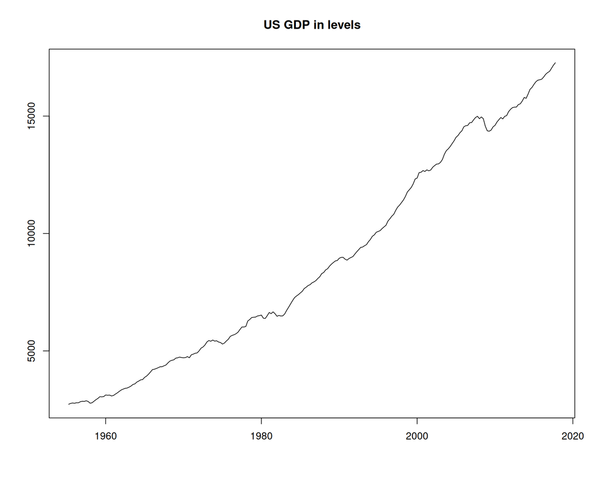

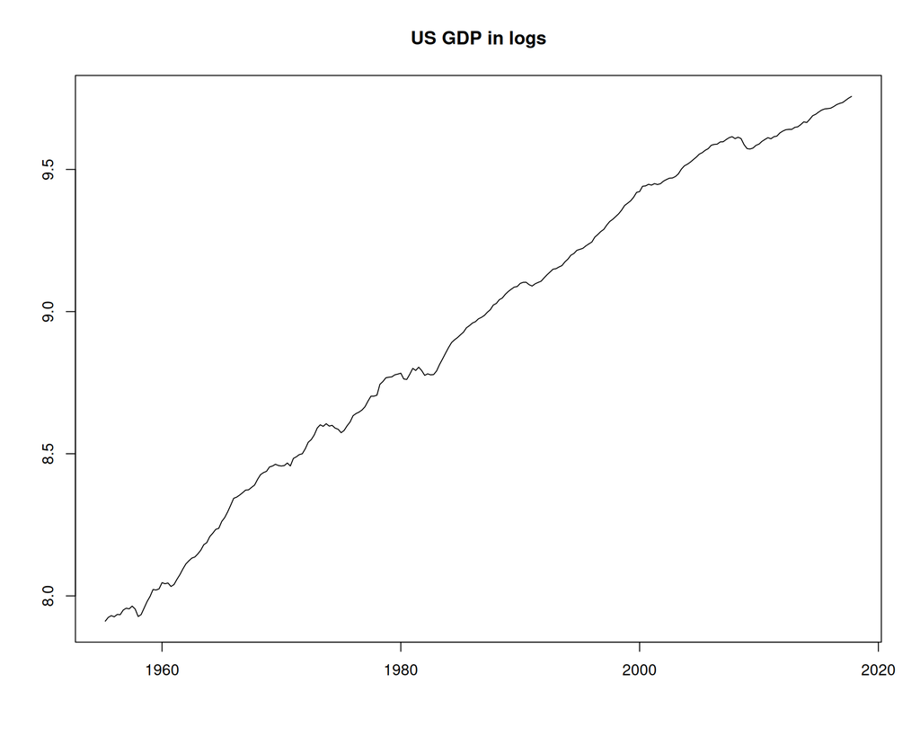

```r
# Time series plot of GDP (logs)
plot(tax, log(macro.dat$GDP),
     type = "l",
     xlab = "",
     ylab = "",
     main = "US GDP in logs")
```

Interpretation

- There seems to be an upward trend in both series.
- Stochastic and/or deterministic trend?
- Why do we care? Different detrending strategies!
  - Stochastic trend: Take first difference for detrending
  - Deterministic trend: Regress on a time trend for detrending

*Add your Interpretation here!*

### Task b)

Extract time window for test

```r
# extract gdp (levels) as time series
gdp.lev.ts.01 <- window(gdp.lev.ts, start = c(1961,0), end = c(2017,4))
```

Specification in general

$$\begin{align*}
Y_t &= \beta_0 + \beta_1 Y_{t-1} + u_t \quad \quad \quad |-Y_{t-1}
\\
\Delta Y_t &= \beta_0 + \left(\beta_1-1\right) Y_{t-1} + u_t \\
\end{align*}$$

$\Rightarrow$ Test whether $\beta_1=1$ or $\delta\equiv\left(\beta_1-1\right)=0$

Specification and estimation: Case 2

Estimated regression

$$\begin{align*}
\Delta Y_t = \beta_0 + \delta Y_{t-1} + u_t
\end{align*}$$

True process

$$\begin{align*}
\Delta Y_t = u_t
\end{align*}$$

Assumption

$$\begin{align*}
u_t \sim iid\left(0,\sigma^2\right)
\end{align*}$$

```r
# Case 2
df.gdp.02 <- ur.df(y = log(gdp.lev.ts.01), type = "drift", lags = 0)
summary(df.gdp.02)
```

```
##
## ###############################################
## # Augmented Dickey-Fuller Test Unit Root Test #
## ###############################################
##
## Test regression drift
##
##
## Call:
## lm(formula = z.diff ~ z.lag.1 + 1)
##
## Residuals:
##        Min         1Q     Median         3Q        Max
## -0.0290499 -0.0033435  0.0004125  0.0044071  0.0292587
##
## Coefficients:
##              Estimate Std. Error t value Pr(>|t|)
## (Intercept)  0.045443   0.009561   4.753 3.57e-06 ***
## z.lag.1     -0.004199   0.001058  -3.968 9.73e-05 ***
## ---
## Signif. codes:  0 '***' 0.001 '**' 0.01 '*' 0.05 '.' 0.1 ' ' 1
##
## Residual standard error: 0.007868 on 226 degrees of freedom
## Multiple R-squared:  0.06514,    Adjusted R-squared:  0.061
## F-statistic: 15.75 on 1 and 226 DF,  p-value: 0.0000973
##
##
## Value of test-statistic is: -3.9681 113.1373
##
## Critical values for test statistics:
##       1pct  5pct 10pct
## tau2 -3.46 -2.88 -2.57
## phi1  6.52  4.63  3.81
```

Specification and estimation: Case 3

Estimated regression

$$\begin{align*}
\Delta A_t = \beta_1 + \delta y_{t-1} + \mu t + u_t
\end{align*}$$

True process

$$\begin{align*}
\Delta Y_t = \beta_1 + u_t
\end{align*}$$

Assumption

$$\begin{align*}
u_t \sim iid\left(0,\sigma^2\right)
\end{align*}$$

```r
# Case 3
df.gdp.03 <- ur.df(y = log(gdp.lev.ts.01), type = "trend", lags = 0)
summary(df.gdp.03)
```

```
##
## ###############################################
## # Augmented Dickey-Fuller Test Unit Root Test #
## ###############################################
##
## Test regression trend
##
##
## Call:
## lm(formula = z.diff ~ z.lag.1 + 1 + tt)
##
## Residuals:
##        Min         1Q     Median         3Q        Max
## -0.0285893 -0.0035763  0.0005882  0.0040505  0.0295034
##
## Coefficients:
##                Estimate  Std. Error t value Pr(>|t|)
## (Intercept)  0.14813210  0.07865242   1.883   0.0609 .
## z.lag.1     -0.01678405  0.00962601  -1.744   0.0826 .
## tt           0.00009472  0.00007201   1.315   0.1897
## ---
## Signif. codes:  0 '***' 0.001 '**' 0.01 '*' 0.05 '.' 0.1 ' ' 1
##
## Residual standard error: 0.007855 on 225 degrees of freedom
## Multiple R-squared:  0.07227,    Adjusted R-squared:  0.06402
## F-statistic: 8.764 on 2 and 225 DF,  p-value: 0.0002163
##
##
## Value of test-statistic is: -1.7436 76.2452 8.7636
##
## Critical values for test statistics:
##       1pct  5pct 10pct
## tau3 -3.99 -3.43 -3.13
## phi2  6.22  4.75  4.07
## phi3  8.43  6.49  5.47
```

Interpretation

Case

- General principle: Fit a specification that is a plausible description of the data under both,
  - the null and…
  - the alternative hypothesis.
- There seems to an upward trending behavior. This can be due to…
  - a random walk with drift $\left(\delta=0, \beta_1\neq0\right)$, or…
  - a random walk with drift and a time trend $\left(\delta=0, \beta_1>0, \mu>0\right)$, or…
  - a trend stationary process $\left(\delta < 0, \mu>0\right)$.
- $\Rightarrow$ Choose case 3

Test statistic

$$\begin{align*}
t_T &= \frac{-0.0168 - 0}{0.0096} \\
t_T &= -1.75
\end{align*}$$

Conclusion

- Under the $H_0$ of a unit root, $t_T$ is not asymptotically normal distributed.
- Instead, $t_T$ is non-standard distributed whereas the critical values for this sample size are given in Table 2 on the exercise sheet
- Test statistic $\left(-1.75\right)$ is larger than the 10% critical value $\left(-3.13\right)$ for case 3.
- $\Rightarrow$ We cannot reject the $H_0$ that there is a unit root in the log GDP series.

*Add your Interpretation here!*

### Task c)

Test for a unit root in the log GDP series using the augmented Dickey Fuller (ADF) test. Use the estimation results of the appropriate specification depicted in Table 4 on the exercise sheet and the critical values depicted in Table 2 of the exercise sheet. Interpret the results.

Diagnostics of DF specification

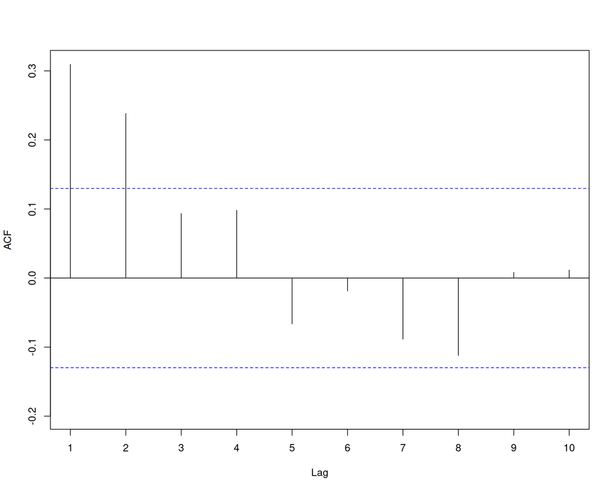

```r
# Get residuals
df.gdp.03.res <- df.gdp.03@res
# Acf/pac of residuals
par(mfrow=c(1,1))
Acf(df.gdp.03.res, lag.max = 10, type = "correlation", plot = T, main = "")
```

Specification in general

General (Case 3 here)

$$\begin{align*}
\Delta Y_t &= \beta_1 + \delta y_{t-1} + \mu t + \sum_{j=1}^{p-1}
\gamma_j \Delta Y_{t-j} + u_t
\end{align*}$$

Assumption

$$\begin{align*}
u_t \sim iid\left(0,\sigma^2\right)
\end{align*}$$

Specification and estimation: 1 lag

$$\begin{align*}
\Delta Y_t &= \beta_1 + \delta Y_{t-1} + \mu t + \gamma_1 \Delta
Y_{t-1} + u_t
\end{align*}$$

```r
# ADF test, case 3, lag 1
adf.gdp.01 <- ur.df(y = log(gdp.lev.ts.01), type = "trend", lags = 1)
summary(adf.gdp.01)
```

```
##
## ###############################################
## # Augmented Dickey-Fuller Test Unit Root Test #
## ###############################################
##
## Test regression trend
##
##
## Call:
## lm(formula = z.diff ~ z.lag.1 + 1 + tt + z.diff.lag)
##
## Residuals:
##        Min         1Q     Median         3Q        Max
## -0.0268453 -0.0039051  0.0001884  0.0043932  0.0311863
##
## Coefficients:
##                Estimate  Std. Error t value Pr(>|t|)
## (Intercept)  0.16955937  0.07613322   2.227   0.0269 *
## z.lag.1     -0.01981383  0.00931719  -2.127   0.0346 *
## tt           0.00012590  0.00006963   1.808   0.0719 .
## z.diff.lag   0.31231829  0.06307644   4.951 1.45e-06 ***
## ---
## Signif. codes:  0 '***' 0.001 '**' 0.01 '*' 0.05 '.' 0.1 ' ' 1
##
## Residual standard error: 0.007477 on 223 degrees of freedom
## Multiple R-squared:  0.1669, Adjusted R-squared:  0.1557
## F-statistic: 14.89 on 3 and 223 DF,  p-value: 7.173e-09
##
##
## Value of test-statistic is: -2.1266 21.4834 5.9571
##
## Critical values for test statistics:
##       1pct  5pct 10pct
## tau3 -3.99 -3.43 -3.13
## phi2  6.22  4.75  4.07
## phi3  8.43  6.49  5.47
```

Specification and estimation: 2 lags

$$\begin{align*}
\Delta Y_t &= \beta_1 + \delta Y_{t-1} + \mu t + \gamma_1 \Delta
Y_{t-1} + \gamma_2 \Delta Y_{t-2} + u_t
\end{align*}$$

```r
# ADF test, case 3, lag 2
adf.gdp.02 <- ur.df(y = log(gdp.lev.ts.01), type = "trend", lags = 2)
summary(adf.gdp.02)
```

```
##
## ###############################################
## # Augmented Dickey-Fuller Test Unit Root Test #
## ###############################################
##
## Test regression trend
##
##
## Call:
## lm(formula = z.diff ~ z.lag.1 + 1 + tt + z.diff.lag)
##
## Residuals:
##       Min        1Q    Median        3Q       Max
## -0.026030 -0.003907  0.000312  0.004469  0.032450
##
## Coefficients:
##                Estimate  Std. Error t value  Pr(>|t|)
## (Intercept)  0.17229808  0.07684137   2.242    0.0259 *
## z.lag.1     -0.02032045  0.00940500  -2.161    0.0318 *
## tt           0.00013392  0.00007022   1.907    0.0578 .
## z.diff.lag1  0.26305937  0.06556398   4.012 0.0000823 ***
## z.diff.lag2  0.16611532  0.06576335   2.526    0.0122 *
## ---
## Signif. codes:  0 '***' 0.001 '**' 0.01 '*' 0.05 '.' 0.1 ' ' 1
##
## Residual standard error: 0.007394 on 221 degrees of freedom
## Multiple R-squared:  0.1861, Adjusted R-squared:  0.1714
## F-statistic: 12.64 on 4 and 221 DF,  p-value: 2.815e-09
##
##
## Value of test-statistic is: -2.1606 12.64 4.6023
##
## Critical values for test statistics:
##       1pct  5pct 10pct
## tau3 -3.99 -3.43 -3.13
## phi2  6.22  4.75  4.07
## phi3  8.43  6.49  5.47
```

Specification and estimation: 3 lags

$$\begin{align*}
\Delta Y_t &= \beta_1 + \delta Y_{t-1} + \mu t + \gamma_1 \Delta
Y_{t-1} + \gamma_2 \Delta Y_{t-2} + \gamma_3 \Delta Y_{t-3} + u_t
\end{align*}$$

```r
# ADF test, case 3, lag 3
adf.gdp.03 <- ur.df(y = log(gdp.lev.ts.01), type = "trend", lags = 3)
summary(adf.gdp.03)
```

```
##
## ###############################################
## # Augmented Dickey-Fuller Test Unit Root Test #
## ###############################################
##
## Test regression trend
##
##
## Call:
## lm(formula = z.diff ~ z.lag.1 + 1 + tt + z.diff.lag)
##
## Residuals:
##       Min        1Q    Median        3Q       Max
## -0.026027 -0.003897  0.000252  0.004543  0.032553
##
## Coefficients:
##                Estimate  Std. Error t value Pr(>|t|)
## (Intercept)  0.16823575  0.07882946   2.134 0.033940 *
## z.lag.1     -0.01982013  0.00965130  -2.054 0.041200 *
## tt           0.00013025  0.00007204   1.808 0.071950 .
## z.diff.lag1  0.26311978  0.06686245   3.935 0.000112 ***
## z.diff.lag2  0.16878673  0.06823443   2.474 0.014135 *
## z.diff.lag3 -0.00798436  0.06704069  -0.119 0.905308
## ---
## Signif. codes:  0 '***' 0.001 '**' 0.01 '*' 0.05 '.' 0.1 ' ' 1
##
## Residual standard error: 0.007426 on 219 degrees of freedom
## Multiple R-squared:  0.1819, Adjusted R-squared:  0.1632
## F-statistic: 9.737 on 5 and 219 DF,  p-value: 2.053e-08
##
##
## Value of test-statistic is: -2.0536 11.2675 4.2583
##
## Critical values for test statistics:
##       1pct  5pct 10pct
## tau3 -3.99 -3.43 -3.13
## phi2  6.22  4.75  4.07
## phi3  8.43  6.49  5.47
```

Specification and estimation: 4 lags

$$\begin{align*}
\Delta Y_t &= \beta_1 + \delta Y_{t-1} + \mu t + \gamma_1 \Delta
Y_{t-1} + \gamma_2 \Delta Y_{t-2} + \gamma_3 \Delta Y_{t-3} + \gamma_4
\Delta Y_{t-4} + u_t
\end{align*}$$

```r
# ADF test, case 3, lag 4
adf.gdp.04 <- ur.df(y = log(gdp.lev.ts.01), type = "trend", lags = 4)
summary(adf.gdp.04)
```

```
##
## ###############################################
## # Augmented Dickey-Fuller Test Unit Root Test #
## ###############################################
##
## Test regression trend
##
##
## Call:
## lm(formula = z.diff ~ z.lag.1 + 1 + tt + z.diff.lag)
##
## Residuals:
##       Min        1Q    Median        3Q       Max
## -0.025655 -0.004007  0.000079  0.004537  0.032005
##
## Coefficients:
##                Estimate  Std. Error t value Pr(>|t|)
## (Intercept)  0.16715129  0.08061337   2.073 0.039307 *
## z.lag.1     -0.01974089  0.00987293  -1.999 0.046802 *
## tt           0.00013115  0.00007367   1.780 0.076441 .
## z.diff.lag1  0.26295980  0.06708642   3.920 0.000119 ***
## z.diff.lag2  0.15717474  0.06937198   2.266 0.024458 *
## z.diff.lag3 -0.02065991  0.06937923  -0.298 0.766154
## z.diff.lag4  0.05679852  0.06719617   0.845 0.398894
## ---
## Signif. codes:  0 '***' 0.001 '**' 0.01 '*' 0.05 '.' 0.1 ' ' 1
##
## Residual standard error: 0.007443 on 217 degrees of freedom
## Multiple R-squared:  0.1768, Adjusted R-squared:  0.154
## F-statistic: 7.767 on 6 and 217 DF,  p-value: 1.4e-07
##
##
## Value of test-statistic is: -1.9995 9.1218 3.7126
##
## Critical values for test statistics:
##       1pct  5pct 10pct
## tau3 -3.99 -3.43 -3.13
## phi2  6.22  4.75  4.07
## phi3  8.43  6.49  5.47
```

Information criteria

For the lag length selection information criteria such as $AIC$ and $BIC$ can be used.

For this it is important to use the same observations for each specification, i.e., for $p=1$, $p=2$,… and $p=4$ above.

```r
# Call provided urca_ur_df_fun function
adf.gdp.res <- urca_ur_df_fun(y = log(gdp.lev.ts.01), type = c("trend"), lags = 4, selectlags = "AIC")
# Collect information criteria
cri.res <- cbind(rbind(lag_len_crit_fun(adf.gdp.res$lm.res[[1]])$AIC, lag_len_crit_fun(adf.gdp.res$lm.res[[1]])$BIC, lag_len_crit_fun(adf.gdp.res$lm.res[[1]])$t),
                 rbind(lag_len_crit_fun(adf.gdp.res$lm.res[[2]])$AIC, lag_len_crit_fun(adf.gdp.res$lm.res[[2]])$BIC, lag_len_crit_fun(adf.gdp.res$lm.res[[2]])$t),
                 rbind(lag_len_crit_fun(adf.gdp.res$lm.res[[3]])$AIC, lag_len_crit_fun(adf.gdp.res$lm.res[[3]])$BIC, lag_len_crit_fun(adf.gdp.res$lm.res[[3]])$t),
                 rbind(lag_len_crit_fun(adf.gdp.res$lm.res[[4]])$AIC, lag_len_crit_fun(adf.gdp.res$lm.res[[4]])$BIC, lag_len_crit_fun(adf.gdp.res$lm.res[[4]])$t),
                 rbind(lag_len_crit_fun(adf.gdp.res$lm.res[[5]])$AIC, lag_len_crit_fun(adf.gdp.res$lm.res[[5]])$BIC, lag_len_crit_fun(adf.gdp.res$lm.res[[5]])$t))
# Name results
rownames(cri.res) <- c("AIC", "BIC", "T")
colnames(cri.res) <- c("p=0", "p=1", "p=2", "p=3", "p=4")
# Print results
cri.res
```

```
##          p=0      p=1      p=2      p=3      p=4
## AIC  -9.6717  -9.7658  -9.7847  -9.7758  -9.7702
## BIC  -9.6260  -9.7049  -9.7085  -9.6844  -9.6635
## T   224.0000 224.0000 224.0000 224.0000 224.0000
```

Interpretation

Choose specification

- $AIC$ as well as $BIC$ suggest to include two lagged differences.

Test statistic

$$\begin{align*}
t_T &= \frac{-0.0203 - 0}{0.0094} \\
t_T &= -2.160
\end{align*}$$

Conclusion

- Under the $H_0$ of a unit root, $t_T$ is not asymptotically normal distributed.
- Instead, $t_T$ is non-standard distributed whereas the critical values for this sample size are given in Table 2 on the exercise sheet.
- Test statistic $\left(-2.160\right)$ is larger than the 10% critical value $\left(-3.13\right)$ for case 3.
- $\Rightarrow$ We cannot reject the $H_0$ that there is a unit root in the log GDP series.

*Add your Interpretation here!*

## Task 2

US unemployment and trends

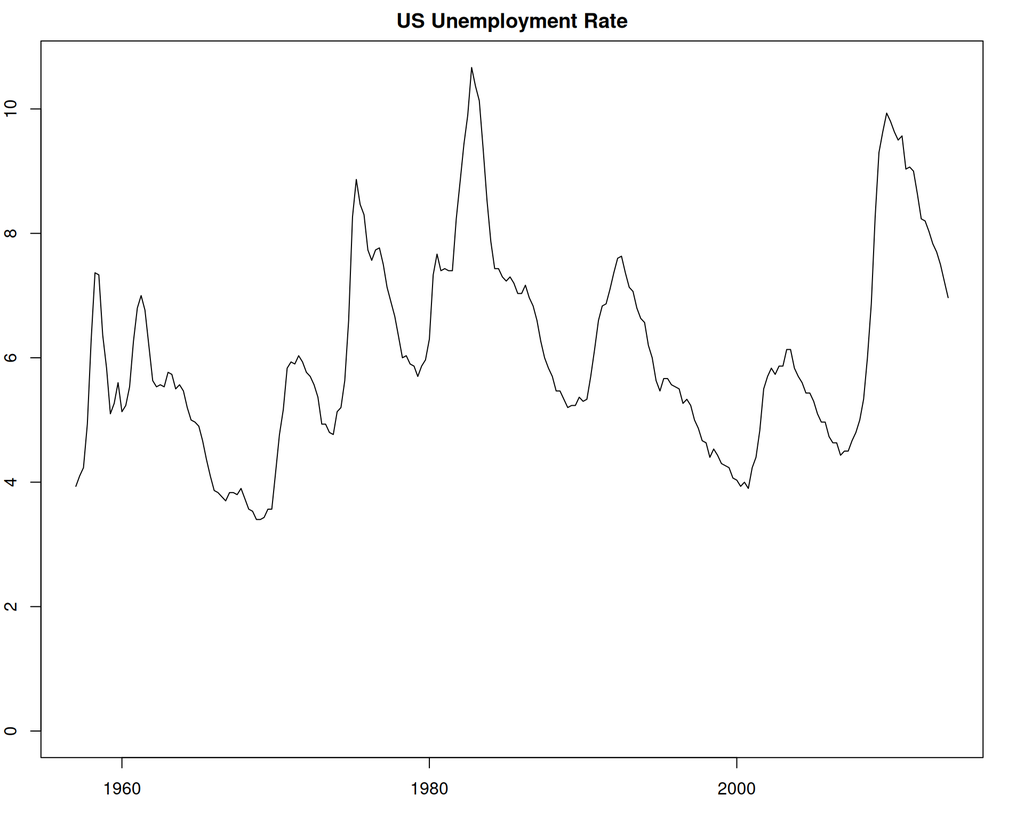

### Task a)

Briefly describe the time series plot of the unemployment rate in Figure 2 on the exercise sheet.

Load data set

```r
# use absolute or relative path to load data
urate.dat <- read.table("us_urate_data.txt",
                        header = TRUE,
                        sep = ",",
                        colClasses = c("character","numeric"))
```

Prepare data set

```r
# extract urate
ura <- urate.dat$URATE
# extract date
tax <- as.Date(urate.dat$DATE)
# extract urate as time series
ur.ts <- ts(urate.dat$URATE, frequency = 4, start = c(1957, 1), end = c(2013, 4))
```

Plot series

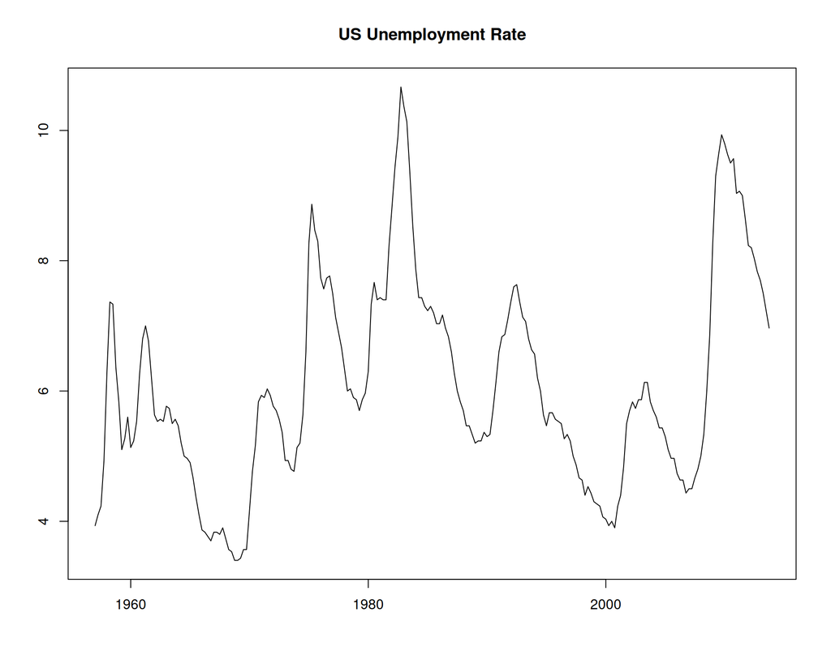

```r
# Time series plot of urate
plot(tax, urate.dat$URATE,
     type = "l",
     xlab = "",
     ylab = "",
     main = "US Unemployment Rate")
```

Interpretation

- There seems to be no clear upward or downward trend in the series.
- There seems to be no deterministic trend.
- There could be still a stochastic trend in the series.

*Add your Interpretation here!*

### Task b)

Test for a unit root in the unemployment rate series using the Dickey Fuller (DF) test. Use the estimation results of the appropriate specification depicted in Table 5 on the exercise sheet and the critical values depicted in Table 2 on the exercise sheet. Interpret the results.

Extract time window for test

```r
# extract urate as time series
ur.ts.01 <- window(ur.ts, start = c(1960,1), end = c(2013,4))
```

Specification and estimation: Case 2

```r
# Case 2
df.ura.02 <- ur.df(y = ur.ts.01, type = "drift", lags = 0)
summary(df.ura.02)
```

```
##
## ###############################################
## # Augmented Dickey-Fuller Test Unit Root Test #
## ###############################################
##
## Test regression drift
##
##
## Call:
## lm(formula = z.diff ~ z.lag.1 + 1)
##
## Residuals:
##      Min       1Q   Median       3Q      Max
## -0.77003 -0.18587 -0.06797  0.09127  1.66910
##
## Coefficients:
##             Estimate Std. Error t value Pr(>|t|)
## (Intercept)  0.14278    0.08981   1.590    0.113
## z.lag.1     -0.02200    0.01423  -1.546    0.124
##
## Residual standard error: 0.3356 on 213 degrees of freedom
## Multiple R-squared:  0.01109,    Adjusted R-squared:  0.006452
## F-statistic:  2.39 on 1 and 213 DF,  p-value: 0.1236
##
##
## Value of test-statistic is: -1.5458 1.2642
##
## Critical values for test statistics:
##       1pct  5pct 10pct
## tau2 -3.46 -2.88 -2.57
## phi1  6.52  4.63  3.81
```

Specification and estimation: Case 3

```r
# Case 3
df.ura.03 <- ur.df(y = ur.ts.01, type = "trend", lags = 0)
summary(df.ura.03)
```

```
##
## ###############################################
## # Augmented Dickey-Fuller Test Unit Root Test #
## ###############################################
##
## Test regression trend
##
##
## Call:
## lm(formula = z.diff ~ z.lag.1 + 1 + tt)
##
## Residuals:
##      Min       1Q   Median       3Q      Max
## -0.76476 -0.19108 -0.06640  0.09145  1.67564
##
## Coefficients:
##               Estimate Std. Error t value Pr(>|t|)
## (Intercept)  0.1361415  0.0922518   1.476    0.141
## z.lag.1     -0.0231198  0.0146645  -1.577    0.116
## tt           0.0001246  0.0003800   0.328    0.743
##
## Residual standard error: 0.3363 on 212 degrees of freedom
## Multiple R-squared:  0.0116, Adjusted R-squared:  0.002271
## F-statistic: 1.244 on 2 and 212 DF,  p-value: 0.2904
##
##
## Value of test-statistic is: -1.5766 0.8751 1.2436
##
## Critical values for test statistics:
##       1pct  5pct 10pct
## tau3 -3.99 -3.43 -3.13
## phi2  6.22  4.75  4.07
## phi3  8.43  6.49  5.47
```

Interpretation

- Chose Case 2 as the process is either…
  - a random walk without drift, or…
  - a stationary process with a constant.
  - $\Rightarrow$ Choose case 2.
- Test statistic $\left(-1.546\right)$ is larger than the 10% critical value $\left(-2.57\right)$ for case 2.
- $\Rightarrow$ We cannot reject the $H_0$ that there is a unit root in the unemployment series.

*Add your Interpretation here!*

### Task c)

Test for a unit root in the unemployment rate series using the augmented Dickey Fuller (ADF) test. Use the estimation results of the appropriate specification depicted in Table 6 on the exercise sheet and the critical values depicted in Table 2 on the exercise sheet. Interpret the results.

Diagnostics of DF specification

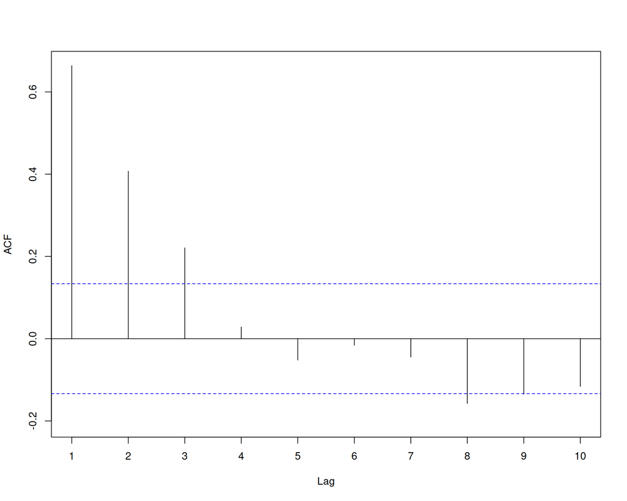

```r
# Get residuals
df.ura.02.res <- df.ura.03@res
# Acf/pac of residuals
par(mfrow=c(1,1))
Acf(df.ura.02.res, lag.max = 10, type = "correlation", plot = T, main = "")
```

Specification and estimation: 1 lag

```r
# ADF test, case 2, lag 1
adf.ura.01 <- ur.df(y = ur.ts.01, type = "drift", lags = 1)
summary(adf.ura.01)
```

```
##
## ###############################################
## # Augmented Dickey-Fuller Test Unit Root Test #
## ###############################################
##
## Test regression drift
##
##
## Call:
## lm(formula = z.diff ~ z.lag.1 + 1 + z.diff.lag)
##
## Residuals:
##      Min       1Q   Median       3Q      Max
## -0.70805 -0.15819 -0.02469  0.12825  1.02525
##
## Coefficients:
##             Estimate Std. Error t value Pr(>|t|)
## (Intercept)  0.22689    0.06658   3.408 0.000784 ***
## z.lag.1     -0.03692    0.01055  -3.499 0.000570 ***
## z.diff.lag   0.68092    0.05056  13.467  < 2e-16 ***
## ---
## Signif. codes:  0 '***' 0.001 '**' 0.01 '*' 0.05 '.' 0.1 ' ' 1
##
## Residual standard error: 0.2473 on 211 degrees of freedom
## Multiple R-squared:  0.4681, Adjusted R-squared:  0.4631
## F-statistic: 92.86 on 2 and 211 DF,  p-value: < 2.2e-16
##
##
## Value of test-statistic is: -3.4987 6.1248
##
## Critical values for test statistics:
##       1pct  5pct 10pct
## tau2 -3.46 -2.88 -2.57
## phi1  6.52  4.63  3.81
```

Specification and estimation: 2 lags

```r
# ADF test, case 2, lag 2
adf.ura.02 <- ur.df(y = ur.ts.01, type = "drift", lags = 2)
summary(adf.ura.02)
```

```
##
## ###############################################
## # Augmented Dickey-Fuller Test Unit Root Test #
## ###############################################
##
## Test regression drift
##
##
## Call:
## lm(formula = z.diff ~ z.lag.1 + 1 + z.diff.lag)
##
## Residuals:
##      Min       1Q   Median       3Q      Max
## -0.70120 -0.15839 -0.02579  0.12822  1.02577
##
## Coefficients:
##              Estimate Std. Error t value Pr(>|t|)
## (Intercept)  0.222738   0.068637   3.245  0.00137 **
## z.lag.1     -0.036391   0.010904  -3.337  0.00100 **
## z.diff.lag1  0.683442   0.067366  10.145  < 2e-16 ***
## z.diff.lag2 -0.005362   0.069217  -0.077  0.93832
## ---
## Signif. codes:  0 '***' 0.001 '**' 0.01 '*' 0.05 '.' 0.1 ' ' 1
##
## Residual standard error: 0.248 on 209 degrees of freedom
## Multiple R-squared:  0.4679, Adjusted R-squared:  0.4603
## F-statistic: 61.26 on 3 and 209 DF,  p-value: < 2.2e-16
##
##
## Value of test-statistic is: -3.3373 5.57
##
## Critical values for test statistics:
##       1pct  5pct 10pct
## tau2 -3.46 -2.88 -2.57
## phi1  6.52  4.63  3.81
```

Specification and estimation: 3 lags

```r
# ADF test, case 2, lag 3
adf.ura.03 <- ur.df(y = ur.ts.01, type = "drift", lags = 3)
summary(adf.ura.03)
```

```
##
## ###############################################
## # Augmented Dickey-Fuller Test Unit Root Test #
## ###############################################
##
## Test regression drift
##
##
## Call:
## lm(formula = z.diff ~ z.lag.1 + 1 + z.diff.lag)
##
## Residuals:
##      Min       1Q   Median       3Q      Max
## -0.69962 -0.15587 -0.02647  0.12629  1.03548
##
## Coefficients:
##              Estimate Std. Error t value Pr(>|t|)
## (Intercept)  0.217805   0.070008   3.111  0.00213 **
## z.lag.1     -0.035973   0.011146  -3.227  0.00145 **
## z.diff.lag1  0.675173   0.067192  10.048  < 2e-16 ***
## z.diff.lag2 -0.004911   0.081870  -0.060  0.95223
## z.diff.lag3  0.003996   0.068860   0.058  0.95378
## ---
## Signif. codes:  0 '***' 0.001 '**' 0.01 '*' 0.05 '.' 0.1 ' ' 1
##
## Residual standard error: 0.2467 on 207 degrees of freedom
## Multiple R-squared:  0.467,  Adjusted R-squared:  0.4567
## F-statistic: 45.34 on 4 and 207 DF,  p-value: < 2.2e-16
##
##
## Value of test-statistic is: -3.2273 5.2113
##
## Critical values for test statistics:
##       1pct  5pct 10pct
## tau2 -3.46 -2.88 -2.57
## phi1  6.52  4.63  3.81
```

Specification and estimation: 4 lags

```r
# ADF test, case 2, lag 3
adf.ura.04 <- ur.df(y = ur.ts.01, type = "drift", lags = 4)
summary(adf.ura.04)
```

```
##
## ###############################################
## # Augmented Dickey-Fuller Test Unit Root Test #
## ###############################################
##
## Test regression drift
##
##
## Call:
## lm(formula = z.diff ~ z.lag.1 + 1 + z.diff.lag)
##
## Residuals:
##      Min       1Q   Median       3Q      Max
## -0.72172 -0.14370 -0.03654  0.12591  1.07666
##
## Coefficients:
##              Estimate Std. Error t value Pr(>|t|)
## (Intercept)  0.192741   0.071560   2.693  0.00766 **
## z.lag.1     -0.031802   0.011423  -2.784  0.00587 **
## z.diff.lag1  0.669524   0.067831   9.870  < 2e-16 ***
## z.diff.lag2 -0.009539   0.081839  -0.117  0.90732
## z.diff.lag3  0.076120   0.081739   0.931  0.35282
## z.diff.lag4 -0.111783   0.068758  -1.626  0.10554
## ---
## Signif. codes:  0 '***' 0.001 '**' 0.01 '*' 0.05 '.' 0.1 ' ' 1
##
## Residual standard error: 0.2463 on 205 degrees of freedom
## Multiple R-squared:  0.4675, Adjusted R-squared:  0.4545
## F-statistic: 35.99 on 5 and 205 DF,  p-value: < 2.2e-16
##
##
## Value of test-statistic is: -2.7841 3.8768
##
## Critical values for test statistics:
##       1pct  5pct 10pct
## tau2 -3.46 -2.88 -2.57
## phi1  6.52  4.63  3.81
```

Information criteria

For the lag length selection information criteria such as $AIC$ and $BIC$ can be used.

For this it is importatn to use the same observations for each specification, i.e., for $p=1$, $p=2$,… and $p=4$ above.

```r
# Call provided urca_ur_df_fun function
adf.ura.res <- urca_ur_df_fun(y = ur.ts, type = c("drift"), lags = 4, selectlags = "AIC")
# Collect information criteria
cri.res <- cbind(rbind(lag_len_crit_fun(adf.ura.res$lm.res[[1]])$AIC, lag_len_crit_fun(adf.ura.res$lm.res[[1]])$BIC, lag_len_crit_fun(adf.ura.res$lm.res[[1]])$t),
                 rbind(lag_len_crit_fun(adf.ura.res$lm.res[[2]])$AIC, lag_len_crit_fun(adf.ura.res$lm.res[[2]])$BIC, lag_len_crit_fun(adf.ura.res$lm.res[[2]])$t),
                 rbind(lag_len_crit_fun(adf.ura.res$lm.res[[3]])$AIC, lag_len_crit_fun(adf.ura.res$lm.res[[3]])$BIC, lag_len_crit_fun(adf.ura.res$lm.res[[3]])$t),
                 rbind(lag_len_crit_fun(adf.ura.res$lm.res[[4]])$AIC, lag_len_crit_fun(adf.ura.res$lm.res[[4]])$BIC, lag_len_crit_fun(adf.ura.res$lm.res[[4]])$t),
                 rbind(lag_len_crit_fun(adf.ura.res$lm.res[[5]])$AIC, lag_len_crit_fun(adf.ura.res$lm.res[[5]])$BIC, lag_len_crit_fun(adf.ura.res$lm.res[[5]])$t))
# Name results
rownames(cri.res) <- c("AIC", "BIC", "T")
colnames(cri.res) <- c("p=0", "p=1", "p=2", "p=3", "p=4")
# Print results
cri.res
```

```
##          p=0      p=1      p=2      p=3      p=4
## AIC  -2.0858  -2.6449  -2.6413  -2.6333  -2.6301
## BIC  -2.0552  -2.5991  -2.5802  -2.5569  -2.5384
## T   223.0000 223.0000 223.0000 223.0000 223.0000
```

Interpretation

*Add your Interpretation here!*

Back To *Start*